# Detect, elect, connect

Week 8 · Chapter 9 · Complex Cognitive Processes

Study · Week 8

Read Chapter 9 of the textbook (Eggen & Kauchak, 2025) before you read this brief. In Week 6 you studied what the mind can hold, and in Week 7 what it builds. This week you study what learners can **do** with what they built: think critically, think creatively, and carry an idea from the situation where they learned it to a new one.

About 25 minutes: reading, one problem you should genuinely try, and 8 quick checks.

Pair this with **the Walkthrough**, a 13-minute video in which I decide what Carlos’s 19/20 was actually measuring, and I am not sure it was only one thing.

**This week runs online for both sections.** Tuesday’s session is a page, so there is no class meeting. Read this brief first, because the page assumes it.

## The claim you already believe

**Many people believe that a student who can do the homework has learned the concept.** Carlos scored 19 of 20. Five days later he could not start a problem that used the same idea in a different context, and he asked *“which type is it?”* Either he forgot in five days, which does not match what Week 6 says about forgetting, or the homework was measuring something else.

Begin with a problem of your own.

Commit first and try the problem

You are a doctor. A patient has an inoperable tumor in the stomach. A kind of ray can destroy it, but at the intensity needed to destroy the tumor, the ray also destroys the healthy tissue it passes through. At lower intensities the ray is harmless to tissue, and harmless to the tumor.

**How do you destroy the tumor without destroying the healthy tissue?** Write your best attempt, even if it is *“I don’t see it.”*

Keep your answer, and read this second problem.

**A general wants to capture a fortress at the center of a country. Many roads radiate out from it. All are mined: a small group can pass safely, but a large force detonates the mines. A full-scale direct attack is impossible.**

The general divides his army into small groups, sends each down a different road, and has them converge on the fortress at the same moment. The fortress falls.

Most people who read the fortress problem *after* attempting the tumor see the solution immediately: many weak rays from many directions, converging on the tumor. Most people who read the tumor problem alone, about nine in ten in Gick and Holyoak’s (1980) study, do not solve it. Most people who read the fortress *first*, and then the tumor, **still do not solve it** unless they are told that the two are related.

This last finding introduces the main idea of the week. People had the knowledge, but they did not *detect* that it was relevant.

## Transfer: detect, elect, connect

Transfer: using what was learned in one context in another. The new context can be near or far, and the result can help or hurt. Teachers always hope for transfer, because nobody teaches percentages so that students can do the worksheet.

Perkins and Salomon (2012) describe three steps that have to happen:

Detect: notice that something you know is relevant here. The fortress readers who failed the tumor problem had the idea and did not detect it. Detection depends on **structure**. The two problems share a structure and nothing else, and novices see surfaces.

Elect: decide to use it. The learner chooses to use prior knowledge, when the alternative is to say *“we never learned this.”* Motivation enters cognition at this step, because learners judge in a second whether trying is worth the cost, and they usually decide against it.

Connect: work out how it applies. The learner maps the old structure onto the new case: rays are soldiers, the tumor is the fortress, and intensity is force. Mapping takes effort, and it produces learning that lasts.

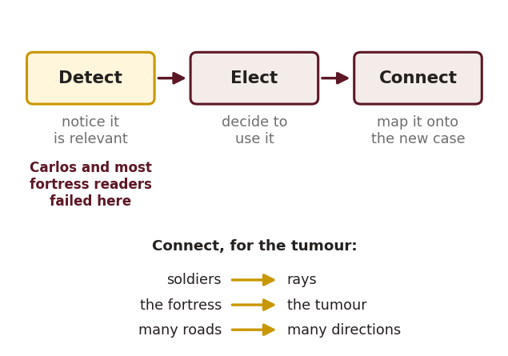

Three steps for transfer (Perkins & Salomon, 2012). Most people who fail the tumor problem fail at the first one.

Carlos failed at **detect**. He had the procedure, with nineteen of twenty correct, and he did not recognize the jacket problem as an instance of it, because every instance he had practiced looked the same. **Twenty problems that share a surface teach students to detect the surface.**

Check yourself

A student reads a word problem about mixing paint, sees that it is a ratio problem, and says *“we never did paint problems, so I’ll skip it.”* Where did transfer break?

She detected it She saw that it was a ratio problem. Detection worked.

Yes She noticed the relevance and decided not to reach back. *“We never learned this”* is a failure to elect.

She never got there Connect is mapping the old structure onto the new case. She stopped before trying.

A new surface is the point Transfer is tested when the structure is the same and the surface is new.

### Kinds of transfer

Positive · negative Prior learning helps in positive transfer and gets in the way in negative transfer. Consider *sit / seat* and *chip / cheap*: Spanish has five vowel sounds, English has about fourteen, and the five keep winning. *Embarazada* ≠ embarrassed. A teacher who reads *multiple intelligences* as *learning styles* has transferred a schema where it does not apply.

Near · far: also *low-road · high-road*. **Near / low-road** transfer occurs between similar contexts, is automatic, and is built by practice. Examples are homework that matches the worked example and a licensure exam in the same format as the practice quiz. **Far / high-road** transfer occurs between different contexts, is deliberate, and is built by abstraction. Examples are using percentages to check a phone bill and using this course to understand a real classroom. Most practice builds near transfer, which takes less effort. Most teachers *want* far transfer, and near transfer does not produce it automatically.

**The twenty generated problems built near transfer, perfectly.** Everyone scored well. Compound interest is the same concept with a different surface and a new element, and the class could not solve it. The tool did exactly what the teacher asked, which was *twenty similar problems*, and *similar* was the error. A design for transfer would have asked for twenty problems that share the structure and **vary everything else.**

True or false?

Practising twenty similar problems is the best preparation for using an idea in a new situation.

Not quite Twenty similar problems build **near** transfer and teach students to detect the surface. Far transfer needs varied surfaces and an extracted principle.

Right Similar practice builds near transfer. Varied practice builds the detection that far transfer needs.

### Strategies that build transfer

The table lists the strategies you will use on the async page:

| Strategy | Builds | Cost |
| --- | --- | --- |
| Practice in **similar** contexts | near transfer, automaticity | none for far |
| **Vary** the practice: surfaces, contexts, domains | detection of structure | slower, feels harder |
| **Extract the principle** explicitly: *what is the same about these three?* | high-road transfer | needs the learner to do the extracting |
| **Investigate connections** — analogies, *and* where they break | mapping skill | a bad analogy transfers the wrong thing |
| **Teach self-monitoring**: *have I seen this structure before?* | detect, elect | metacognition has to be taught, not assumed |

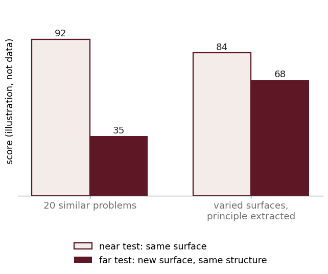

Similar practice wins the near test and loses the far one. Varied practice costs a little on the near test and pays on the far one.

## Critical thinking

Critical thinking: analysis, evaluation, inference. A critical thinker breaks a claim into parts, judges the credibility and relevance of what supports it, and draws only the conclusion that the evidence supports.

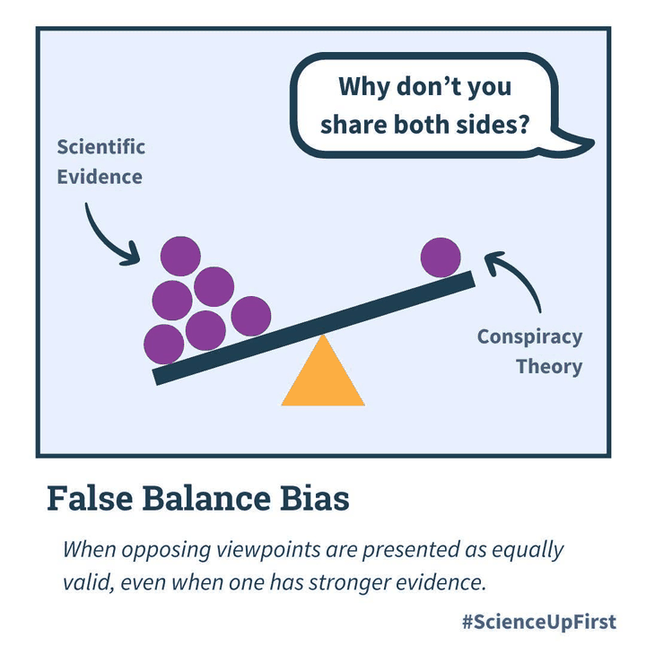

False balance. Image: #ScienceUpFirst.

**Evaluation means weighing what supports each side.** *“Share both sides”* sounds fair, but it skips that step, because two positions get equal time whatever their evidence weighs. Ask of any disagreement: can evidence settle it?

True or false?

Giving two positions equal time is the fair, critical-thinking approach to a disagreement.

Not quite Equal time skips the evaluation step. Critical thinking weighs what supports each side, and the weights are often unequal.

Right Fairness requires weighing the evidence. Equal time for unequal evidence is false balance.

Argumentation Deductive reasoning goes from a general rule to a case, and inductive reasoning goes from cases to a general rule. Abductive reasoning goes to the best available explanation of incomplete evidence. Most classroom reasoning, and most diagnosis in this course, is abductive.

Check yourself

A teacher notices a student’s grades dropping. He looks tired and has stopped turning in homework. She decides the most likely explanation is a problem at home, and plans to find out more. Which kind of reasoning is this?

No general rule applied Deduction runs from a rule to a case. She started from the evidence.

Not a general rule Induction builds a general rule from many cases. This is one student.

Yes She chooses the best available explanation of incomplete evidence and stays open to more. Most classroom diagnosis works this way.

Only if she stops checking Mental set is solving the new problem the old way without checking. She plans to find out more.

Mental set · functional fixedness Mental set is solving the new problem the way the last one was solved. Functional fixedness is seeing an object only in its usual role. Ethan said, *“up 20%, down 20%, they cancel.”* His set was *percentages are symmetric*, and he never checked it.

Ethan reached the wrong answer in ninety seconds and felt finished, whereas Maddie reached the right one slowly and felt unfinished. **Confidence tells you about the thinker, and it does not tell you whether the answer is right.** A tool that returns a confident answer in four seconds has the same problem.

True or false?

Feeling confident about an answer is good evidence that it is correct.

Not quite Ethan was confident and wrong in ninety seconds. Confidence tells you about the thinker.

Right The fast answer arrives with a feeling of rightness whether it is right or not.

**Ethan’s response is a default, and we should not read it as a flaw.** The chapter explains it with dual-process theory (Kahneman, 2011). A fast, intuitive system produces the answer that *fits*, and a slower, effortful system checks it, if it is engaged. It usually is not, because the fast answer arrives with a feeling of rightness. Critical thinking is largely the habit of checking when the feeling says you do not need to. Your Friction Move this week (**bat and ball**) tests whether you check, and whether the tool does.

## Creativity: divergent and convergent thinking

Divergent thinking: generating many possibilities. It includes fluency (how many), flexibility (how many kinds) and originality (how unusual). Maddie’s three restarts and *“maybe it’s always 96%”* are divergent production under time pressure.

Convergent thinking: choosing the one that works. The thinker evaluates the candidates against constraints and commits to one. Creativity is *both*: a student who generates and cannot converge abandons the task, and a student who converges without generating solves the wrong problem well.

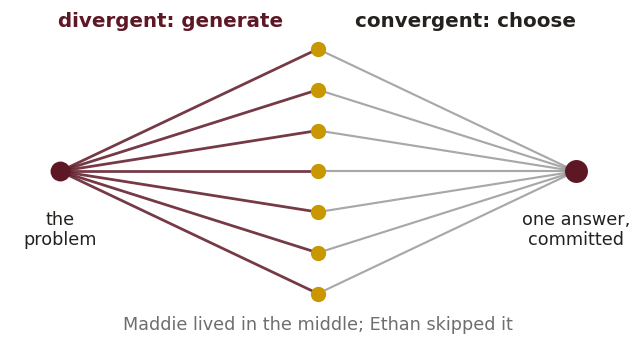

Creativity needs both halves: generate many, then choose one and commit.

True or false?

The student who produces the most ideas is the most creative.

Not quite Generating is half. Creativity also needs **convergent** thinking: choosing the idea that works and committing to it.

Right A student with many ideas and no choice abandons the task. Creativity is generating *and* choosing.

**Maddie did both halves, and the task only had room for one.** She generated three restarts, a second price and a pattern (*“maybe it’s always 96%”*). She also converged, because the right answer is in her work. Nothing told her when to stop generating and commit, so she ended on *“I don’t know if that’s what you wanted”* and ran out of time. A task that asks for both has to make room for both, in order, and tell students which one is happening now.

## Novices and experts

The chapter’s account of expertise explains why Carlos failed detection. Experts do not have bigger working memories. They have **schemas organized around deep structure**, so they recognize a new problem as a kind of thing. Novices organize around **surface features**, such as the objects in the problem or the wording, because that is all they can see yet.

For this reason, telling a novice to *look for the structure* does not work. Teachers have to show novices several surfaces with one structure until they notice the structure. This is the argument for varied practice and against twenty similar problems.

## Reasoning in AI

A model’s chain-of-thought is a **worked example** with ordered steps that look like reasoning. Sometimes it is reasoning. Sometimes it is a pattern that matches the surface of the problem and produces the answer that usually follows that surface, which is what Ethan did. The bat-and-ball problem is a classic test because the intuitive answer is so strongly associated with the wording that both people and models produce it unless something makes them check.

In Milestone 2, you apply these ideas to your own tool in two lines. Part 2 states **what must transfer**, and Part 5 describes **the measure that would show it did**. The measure has to be a new case, because another problem of the same kind cannot show transfer.

## Check yourself

Check yourself

A student learned to write a persuasive essay in class, then writes one on a new topic for homework. Which kind of transfer?

Too far The genre, structure and setting are the same, and only the topic is new. The contexts are similar, so the application is close to automatic.

Yes The context is similar, the skill is practiced, and the surface changes a little. Most homework builds this kind of transfer, and it is worth building. Far transfer would be using the persuasive structure in a science report or a job application.

Nothing is getting in the way Negative transfer is prior learning that hurts. Here it helps.

It is transfer The topic changed, so the context is new, however near. Transfer is a matter of distance, and it does not have a yes or no answer.

Check yourself

A Spanish speaker learning English reads *embarazada* in a Spanish text and, thinking in English now, assumes it means *embarrassed*. This is:

The direction is wrong Something was transferred, but it hurt. Positive transfer helps.

Wrong on both counts The contexts are close (two languages, one word-shape) and the result is an error.

Yes The reader detected a surface similarity, the letters, and connected it to the wrong structure. Detection works this way before a learner has enough varied cases to notice which similarities matter. The word means *pregnant*.

Different concept Functional fixedness is seeing an object only in its usual role. This is a mapping error between two knowledge bases.

Bring to Tuesday’s page **Your answer to case question 1**, which explains in the chapter’s words what the homework was measuring.

**Your tumor attempt** from above. We will compare attempts in class.

**One concept from your subject that students can do on the homework and cannot use outside it.** You will write the item that tells the difference.

The retrieval check closes **Tuesday at noon**, as always. The page begins with the questions that most students missed, and you will see the item statistics on it.

*This week feeds Milestone 2, Part 2 (reason, critique, create, transfer) and Part 5 (a new case as the measure).*

## Sources

Baron, J. (1985). *Rationality and intelligence.* Cambridge University Press.

Eggen, P. D., & Kauchak, D. P. (2025). *Using educational psychology in teaching* (12th ed.). Pearson. **This week: Chapter 9.**

Frederick, S. (2005). Cognitive reflection and decision making. *Journal of Economic Perspectives, 19*(4), 25–42.

Gick, M. L., & Holyoak, K. J. (1980). Analogical problem solving. *Cognitive Psychology, 12*(3), 306–355.

Kahneman, D. (2011). *Thinking, fast and slow.* Farrar, Straus and Giroux.

Perkins, D. N., & Salomon, G. (2012). Knowledge to go: A motivational and dispositional view of transfer. *Educational Psychologist, 47*(3), 248–258.

Stanovich, K. E., & West, R. F. (1997). Reasoning independently of prior belief and individual differences in actively open-minded thinking. *Journal of Educational Psychology, 89*(2), 342–357.